# R for Big data

2016-10-05

## Course R package

```r
install.packages("drat")
drat::addRepo("rcourses")
install.packages("nclRbig")
library("nclRbig") # No errors
```

If that works, try and get the dependencies

```r
install.packages("nclRbig", dependencies = TRUE)
```

## Who am I?

## Who are you?

## Slides

```r
## This is new. Expect difficulties
vignette("slides1", package="nclRbig")
```

## Update the package

## 1.1 What is Big Data?

## If it's not too personal

> How big is your data?

## 1.1 What is Big Data?

- Voluminous, occupying much RAM and hard disk space
- Variable, within each dataset and between sources
- High in velocity: it's always being generated.

## 1.2 Coping with big data in R

## 1.2 Coping with big data in R

- R loads data into RAM
- Development of a statistical model took more time than the computation.
  - Not with big data

## Small data makes big data

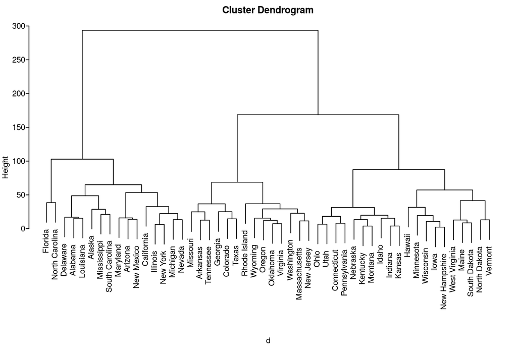

```r
d = dist(USArrests)
fit = hclust(d)
plot(fit, labels=rownames(d))
```

## Small data makes big data

```r
pryr::object_size(USArrests)
```

```
## 5.23 kB
```

```r
pryr::object_size(d)
```

```
## 14.3 kB
```

## Strategies

## Strategies

- Buy more RAM

```r
benchmarkme::get_ram()
```

```
## 16.3 GB
```

- Sampling
- Integration with C++ or Java
- Avoid storing objects in memory

## Background (not in the notes)

- Covered in Efficient R course
- Detailed notes are available at chapter 8 of https://csgillespie.github.io/efficientR/
- Brief overview

## File sizes

- A computer cannot store "numbers" or "letters"
- The only thing a computer can store and work with is bits.
- A bit is binary, it is either a \(0\) or a \(1\).

## Bit Representation

| Bit representation | Character |
| --- | --- |
| \(01000001\) | A |
| \(01000010\) | B |
| \(01000011\) | C |
| \(01000100\) | D |
| \(01000101\) | E |
| \(01010010\) | R |

## Bits and bytes

- Eight bits is one byte
  - Four bits is called a nibble
- So two characters would use two bytes or 16 bits.
- A document containing \(100\) characters would use \(100\) bytes (\(800\) bits).
- This assumes that the file didn't have any other memory overhead, such as font information or meta-data
- An empty `.docx` file takes about 3.7KB of storage

## Standards

- \(1KB = 10^3 = 1000B\)
- \(1MB = 10^6 = 1,000,000B\)
- \(1GB = 10^9 = 1,000,000,000B\)
- \(1TB = 10^12B\)
- \(1PB = 10^15B\)

## Five minute exercise

1. R loads everything into memory, i.e. your computers RAM. How much RAM do you have?
2. Using Google, how much does it cost (in pounds) to double the amount of available RAM?
   - How much does it cost to rent a machine comparable to your laptop in the cloud?